# Data Exploration and Hypothesis Generation

The exploratory data analysis (EDA) process is important because it helps with us learn more about what the data measures, what typical values are, and also identify errors. But EDA is also very helpful for identifying patterns in the data, relationships between variables, and ultimately generate testable hypotheses.

In this lesson, we will learn the basics of summarizing, filtering, and arranging data to learn more about it, and we’ll also learn how to visualize data. Data visualization is an extremely good way to learn about your data. You tell me what give YOU more information. This:

```r
head(table1)
```

| country | year | cases | population |
| --- | --- | --- | --- |
| Afghanistan | 1999 | 745 | 19987071 |
| Afghanistan | 2000 | 2666 | 20595360 |
| Brazil | 1999 | 37737 | 172006362 |
| Brazil | 2000 | 80488 | 174504898 |
| China | 1999 | 212258 | 1272915272 |
| China | 2000 | 213766 | 1280428583 |

or this?

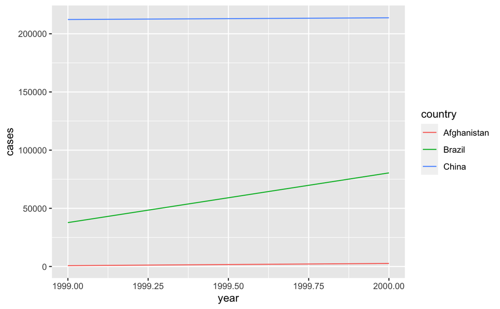

Exactly.

Python and R both have good plotting libraries, and because we can use both languages in R Studio, we can visualize our data using both. Our focus in this lesson, however, will be on learning the extremely powerful visualization package in R called `ggplot2`. `ggplot2` is built around what’s called the “grammar of graphics” which is a system of building data visuals in a way that is easy to describe and understand. Data visualization with `ggplot` is one of the best aspects of using R.

In general in conducting EDA, we want to explore two questions. As Hadley Wickham explains in [Chapter 7 of R for Data Science](https://r4ds.had.co.nz/exploratory-data-analysis.html#questions):

> … two types of questions will always be useful for making discoveries within your data. You can loosely word these questions as:
> 1. What type of variation occurs within my variables?
> 2. What type of covariation occurs between my variables?

# Session Learning Objectives

1. Use descriptive methods to explore data
   - Summarize and aggregate data
   - Filter data
   - Arrange data
2. Use visual methods to explore data
   - Build plots with `ggplot2`
   - Show multiple dimensions of data in one plot
   - Use facets to explore groups
   - Learn how to make your visuals more effective
3. Practice developing hypotheses from EDA methods

# Import the Cleaned Data

Before we jump into things, we need to load the packages we need and import the data we cleaned last time:

```r
library(tidyverse)
flight.data <- read_csv("Documents/my_project/flights_cleaned.csv")
```

Alright, looks good. Let’s get into it.

# Exploring Data with Descriptive Methods

Once we have our data in a tidy format, the next step is to start exploring it to learn more about what information our data has. One of the best ways to do this is with data visualizations, but there are important non-visual ways to explore it as well. In this section we’ll explore how to:

- Summarize and aggregate data
- Filter data
- Arrange data

## Summarizing and Aggregating Data

Summarizing and aggregation are useful because they allow us to answer questions like: “how long is the average flight?”, “which carriers have the longest delays on average?” and “which origin has the most number of carriers?” These questions can easily be answered with the combination of the `group_by()` and `summarize()` functions in R.

`group_by()` puts the data into groups so that we can then perform calculations for each group instead of the entire column of data. `summarize()` collapses our data down to the level of our groups so that we can answer questions at the group-level. For example, which carriers have the longest delays on average? *Note that we probably don’t want an assignment here.*

```r
flight.data %>%
  # lets group the data by carrier
  group_by(carrier) %>%
  # then find the mean delay for each carrier
  summarize(mean_delay = mean(dep_delay))
```

| carrier | mean_delay |
| --- | --- |
| 9E | 16.439574 |
| AA | 8.569130 |
| AS | 5.830748 |
| B6 | 12.967548 |
| DL | 9.223950 |
| EV | 19.838929 |
| F9 | 20.201175 |
| FL | 18.605984 |
| HA | 4.900585 |
| MQ | 10.445381 |

[output cut: 6 more lines]

Which origin has the most number of carriers? To answer this, we’ll use the `n_distinct()` function which calculates the number of distinct values.

```r
flight.data %>%
  group_by(origin) %>%
  summarize(n_carriers = n_distinct(carrier))
```

| origin | n_carriers |
| --- | --- |
| EWR | 12 |
| JFK | 10 |
| LGA | 13 |

It’s also possible to group by multiple groups to get narrower calculations.

### Exercise

1. Find the average departure delay (`dep_delay`) for each `carrier` at each `origin`.
2. What are some other reasons that could contribute to delays? Could you test those reasons with this dataset?

## Filtering Data

Your answer to the last exercise gives some good info, but it’s natural to look at data like that and wonder what the longest average delay was. This is where `filter()` comes in. Let’s filter the data from the last exercise to find the longest delay:

```r
flight.data %>%
  group_by(origin, carrier) %>%
  summarize(avg_delay = mean(dep_delay)) %>%
  # filter the data where avg_delay equals the maximum avg_delay
  filter(avg_delay == max(avg_delay))
```

| origin | carrier | avg_delay |
| --- | --- | --- |
| EWR | OO | 20.83333 |
| JFK | 9E | 18.70266 |
| LGA | F9 | 20.20117 |

Notice that R returned the max delay by each airport. That’s because our data is still grouped. We can get the overall maximum by ungrouping the data after we summarize it:

```r
flight.data %>%
  group_by(origin, carrier) %>%
  summarize(avg_delay = mean(dep_delay)) %>%
  # now ungroup the data
  ungroup() %>%
  # filter the data where avg_delay equals the maximum avg_delay
  filter(avg_delay == max(avg_delay))
```

| origin | carrier | avg_delay |
| --- | --- | --- |
| EWR | OO | 20.83333 |

We can figure out what airline OO is by looking at the `airlines` data included in the `nycflights13` R package:

```r
filter(nycflights13::airlines, carrier == "OO")
```

| carrier | name |
| --- | --- |
| OO | SkyWest Airlines Inc. |

### Exercise

1. Use `filter()` to find the longest distance (`distance`) any flight traveled.

## Arranging Data

Instead of returning only one specific value, like the maximum, you might instead want to arrange the data. This is what `arrange()` is for. Let’s calculate the average delays by origin and carrier and arrange the data so that we can see all the the delays in order:

```r
flight.data %>%
  group_by(origin, carrier) %>%
  summarize(avg_delay = mean(dep_delay)) %>%
  arrange(avg_delay)
```

| origin | carrier | avg_delay |
| --- | --- | --- |
| LGA | US | 3.258991 |
| EWR | US | 3.699723 |
| JFK | HA | 4.900585 |
| EWR | 9E | 5.656329 |
| EWR | AS | 5.830748 |
| JFK | US | 5.865385 |
| LGA | AA | 6.701882 |
| JFK | UA | 7.811300 |
| JFK | DL | 8.288779 |
| LGA | MQ | 8.435163 |

[output cut: 25 more lines]

By default, `arrange()` puts the values in acceding order but we can change that to descending order by wrapping our variable with `desc()` like so:

```r
flight.data %>%
  group_by(origin, carrier) %>%
  summarize(avg_delay = mean(dep_delay)) %>%
  arrange(desc(avg_delay))
```

| origin | carrier | avg_delay |
| --- | --- | --- |
| EWR | OO | 20.833333 |
| LGA | F9 | 20.201175 |
| EWR | EV | 20.049522 |
| LGA | EV | 18.987477 |
| LGA | YV | 18.898897 |
| JFK | 9E | 18.702663 |
| LGA | FL | 18.605984 |
| JFK | EV | 18.520362 |
| EWR | WN | 17.799703 |
| LGA | WN | 17.522044 |

[output cut: 25 more lines]

### Exercise

1. Use `arrange()` to investigate the shortest distances traveled.

# Exploring Data with Visual Methods

## Building Plots with `ggplot2`

`ggplot2` is one of the primary packages included in R’s tidyverse, so I you already loaded tidyverse then you’re good to go.

`ggplot2` builds plots with two basic functions: `ggplot()` and `geom_*()`, where `*` is a placeholder for a number of different `geom`s that are available.

I like to learn by doing, so let’s just start plotting, then I’ll explain things. Let’s build a histogram of flight departure delays `dep_delay`:

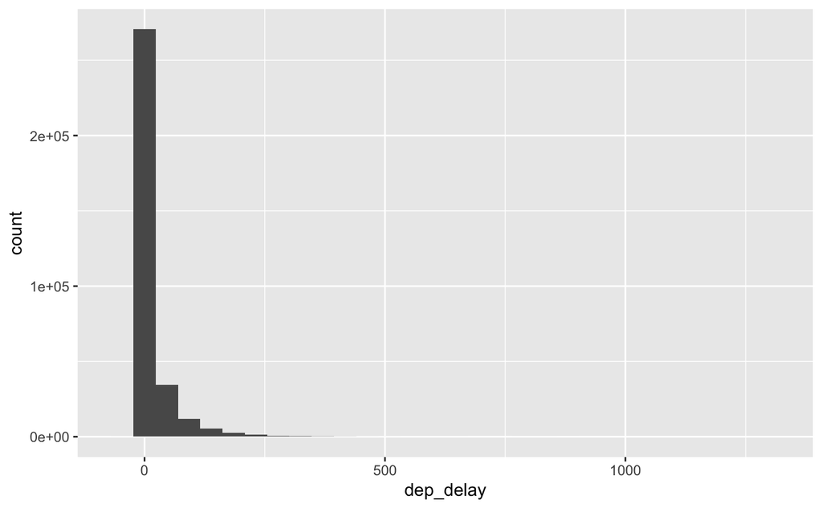

```r
ggplot(data = flight.data, mapping = aes(x = dep_delay)) +
  geom_histogram()
```

Let’s break down this code:

- `ggplot()`: the main plotting function
- `data = flight.data`: set the `data` argument equal to the data that I want to plot
- `mapping = aes(x = dep_delay)`: we always map the values we want to plot to an aesthetic (`aes()`). In this case, we are mapping the x-axis aesthetic to `dep_delay`
- `geom_histogram`: this defines the type of plot to make

It looks like most of the values are close to zero, but this plot already looks suspicious given the how wide the x-axis is. The long x-axis means that extreme values exist, but there aren’t enough to make a bar tall enough we can see. Let’s zoom in to get a better sense of what these values are. We can zoom by limiting the y-axis to a narrower width with `coord_cartesian()`:

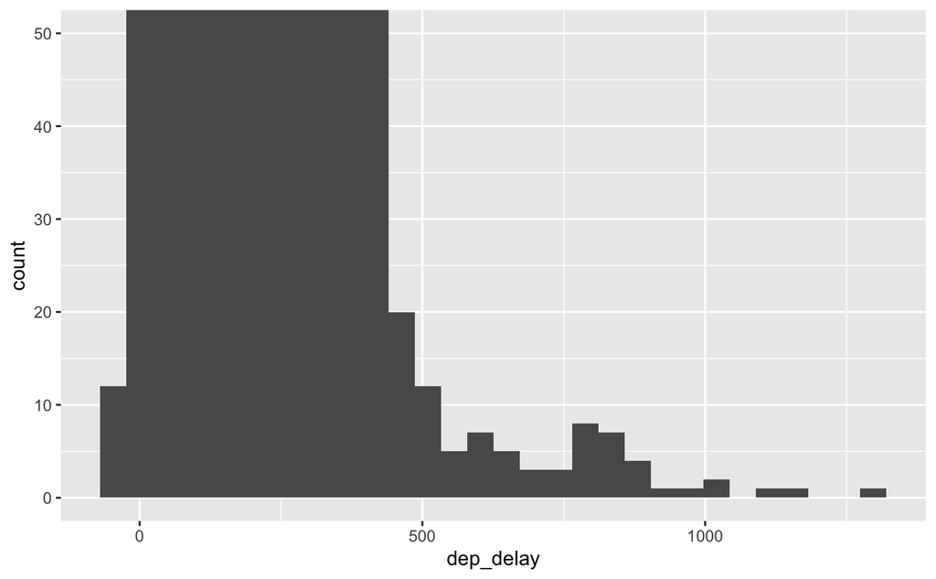

```r
ggplot(data = flight.data, mapping = aes(x = dep_delay)) +
  geom_histogram() +
  coord_cartesian(ylim = c(0, 50))
```

It looks like there are some extreme values and we can see that there are more that just a couple. Let’s use our `arrange()` and `filter()` skills to see what these values are:

```r
flight.data %>%
  filter(dep_delay > 750) %>%
  arrange(desc(dep_delay))
```

| year | month | day | dep_time | dep_delay | arr_time | arr_delay | carrier | tail_num | flight | origin | dest | air_time | distance | hour | minute | tot_delay |
| --- | --- | --- | --- | --- | --- | --- | --- | --- | --- | --- | --- | --- | --- | --- | --- | --- |
| 2013 | 1 | 9 | 641 | 1301 | 1242 | 1272 | HA | N384HA | 51 | JFK | HNL | 640 | 4983 | 6 | 41 | 2573 |
| 2013 | 6 | 15 | 1432 | 1137 | 1607 | 1127 | MQ | N504MQ | 3535 | JFK | CMH | 74 | 483 | 14 | 32 | 2264 |
| 2013 | 1 | 10 | 1121 | 1126 | 1239 | 1109 | MQ | N517MQ | 3695 | EWR | ORD | 111 | 719 | 11 | 21 | 2235 |
| 2013 | 9 | 20 | 1139 | 1014 | 1457 | 1007 | AA | N338AA | 177 | JFK | SFO | 354 | 2586 | 11 | 39 | 2021 |
| 2013 | 7 | 22 | 845 | 1005 | 1044 | 989 | MQ | N665MQ | 3075 | JFK | CVG | 96 | 589 | 8 | 45 | 1994 |
| 2013 | 4 | 10 | 1100 | 960 | 1342 | 931 | DL | N959DL | 2391 | JFK | TPA | 139 | 1005 | 11 | 0 | 1891 |
| 2013 | 3 | 17 | 2321 | 911 | 135 | 915 | DL | N927DA | 2119 | LGA | MSP | 167 | 1020 | 23 | 21 | 1826 |
| 2013 | 6 | 27 | 959 | 899 | 1236 | 850 | DL | N3762Y | 2007 | JFK | PDX | 313 | 2454 | 9 | 59 | 1749 |
| 2013 | 7 | 22 | 2257 | 898 | 121 | 895 | DL | N6716C | 2047 | LGA | ATL | 109 | 762 | 22 | 57 | 1793 |
| 2013 | 12 | 5 | 756 | 896 | 1058 | 878 | AA | N5DMAA | 172 | EWR | MIA | 149 | 1085 | 7 | 56 | 1774 |

[output cut: 18 more lines]

There are 28 flights that had delays of longer than 750 minutes and 5 with over 1000 minutes.

A better way to get a sense of the range of values might be to use a boxplot. Let’s also include airline information to see how the delays vary by airline:

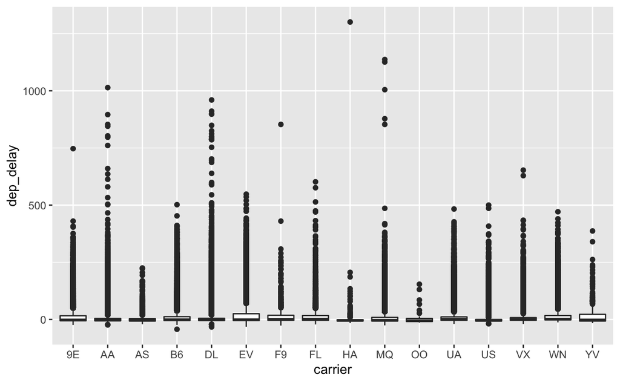

```r
ggplot(data = flight.data, mapping = aes(x = carrier, y = dep_delay)) +
  geom_boxplot()
```

No super helpful, but better. Another option is what’s called a violin plot:

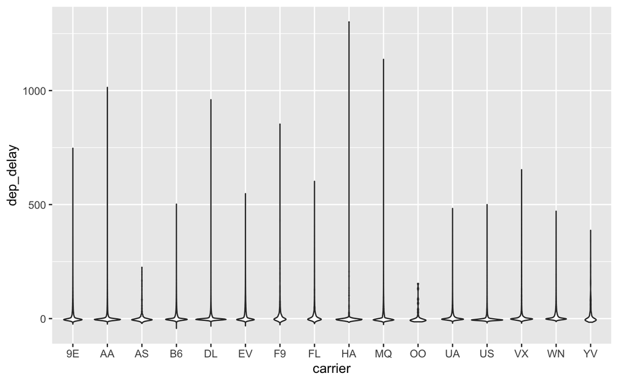

```r
ggplot(data = flight.data, mapping = aes(x = carrier, y = dep_delay)) +
  geom_violin()
```

Are arrival delays any different? Let’s investigate.

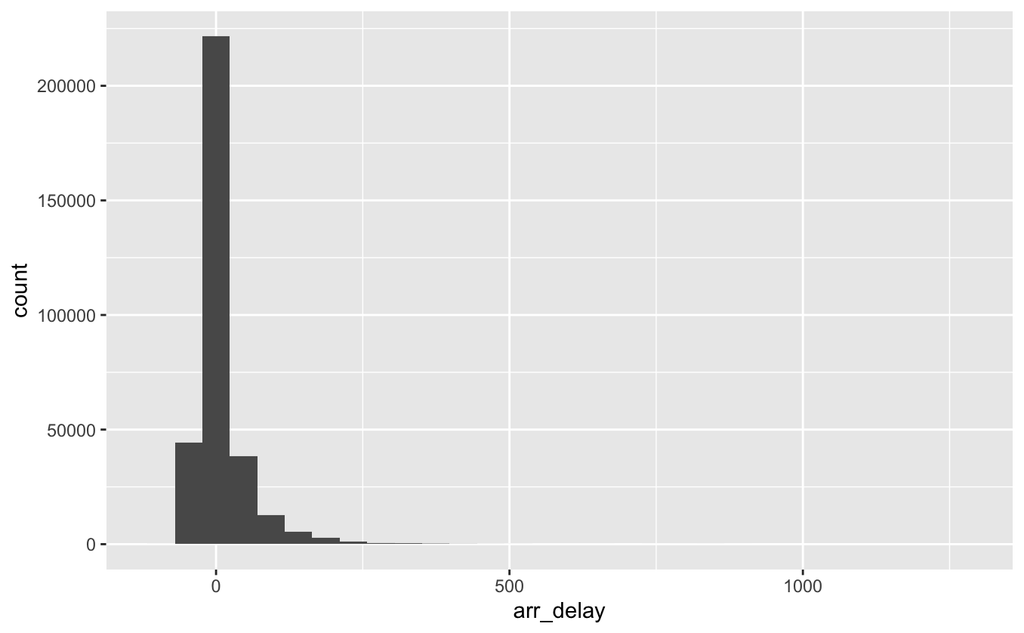

```r
ggplot(data = flight.data, mapping = aes(x = arr_delay)) +
  geom_histogram()
```

Looks like a similar story here.

Instead of using histograms we could also plot the densities. Density plots standardize the count across categories so that the area under the curve equals 1.

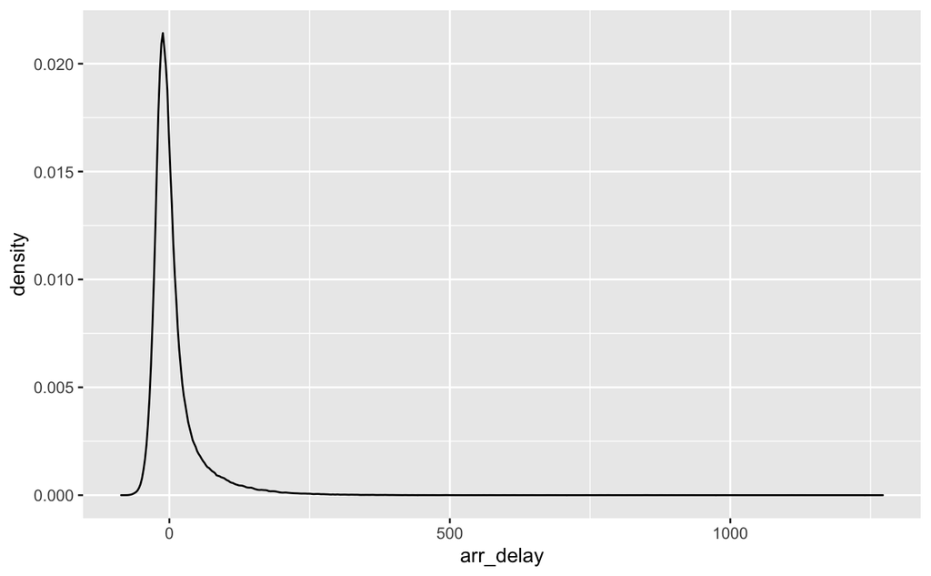

```r
ggplot(data = flight.data, mapping = aes(x = arr_delay)) +
  geom_density()
```

We’ve looked at departure delays and arrival delays independently, but is there a relationship between them? It seems reasonable that if a plane leaves late it will also arrive late, right? Let’s use a scatter plot to look at this relationship. In the scatter plot, we’ll put `dep_delay` on the x-axis and `arr_delay` on the y-axis because we typically think of the `x` variable as explaining the `y` variable:

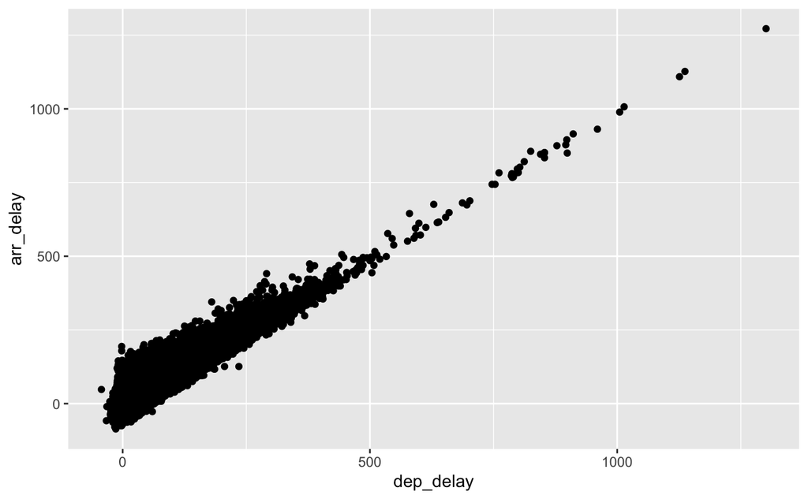

```r
ggplot(data = flight.data, mapping = aes(x = dep_delay, y = arr_delay)) +
  geom_point()
```

That’s a pretty strong relationship.

### Exercises

1. Visualize departure delays `dep_delay` using a frequency polygon `geom_freqpoly`. How does this differ from a density plot?
2. Plot the relationship between `month` and `dep_delay`. Which month has the most delays?

## Visualizing Multiple Dimensions

So far we’ve seen plots of one and two variables, but what if we wanted even more information? For example, what if we wanted to look at the relationship between departure delays and arrival delays by airline? We can do this by mapping the `carrier` to a color like this:

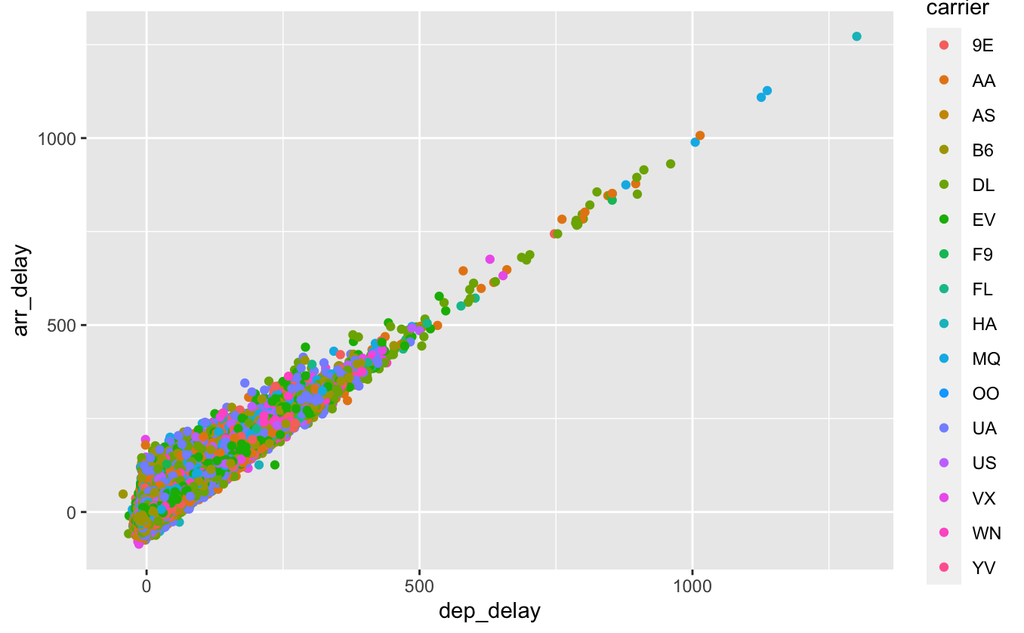

```r
ggplot(data = flight.data,
       mapping = aes(x = dep_delay, y = arr_delay, color = carrier)) +
  geom_point()
```

The color helps a little, but we can make this better. First, let’s try using a hex plot and map carrier to the fill instead of the color:

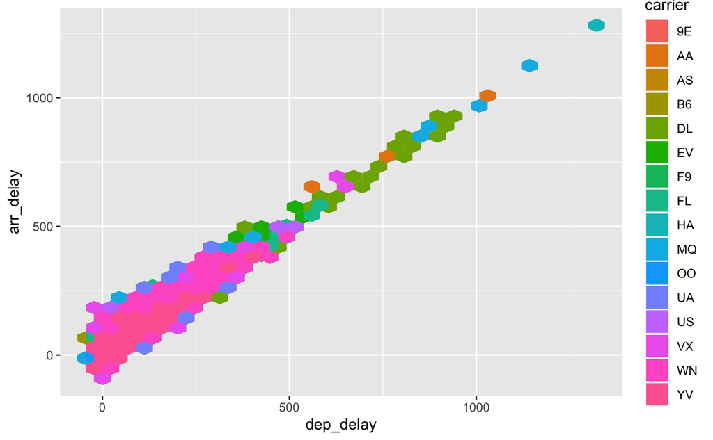

```r
ggplot(data = flight.data,
       mapping = aes(x = dep_delay, y = arr_delay, fill = carrier)) +
  geom_hex()
```

Maybe it’s not the airline that matters, but where the flight leaves from. To check this, we’ll make another hex plot mapping `origin` to the fill:

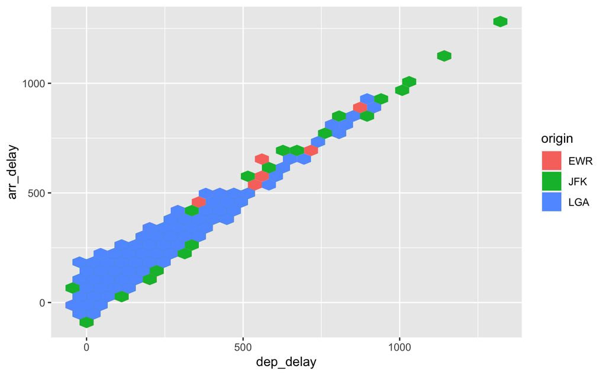

```r
ggplot(data = flight.data,
       mapping = aes(x = dep_delay, y = arr_delay, fill = origin)) +
  geom_hex()
```

How much to average departure delays for each carrier vary by their point of origin? This is a more complicated plot because it requires us to complete a couple steps:

- Compute the average delays by carrier and origin
- Create a plot of average delays by carrier and point of origin